# 2023 Pre-assessment workshop for black rockfish in off Oregon

# Bridging the assessment model from Stock Synthesis 3.24 to 3.30

Since several years have passed from the last assessment model, the Stock Synthesis (SS) modelling framework has undergone many changes. While the specific changes in the model can be found in the model [change log](https://github.com/nmfs-stock-synthesis/stock-synthesis/blob/v3.30.19/Change_log_for_SS_3.30.xlsx?raw=true), here we simply update the model from the older 3.24V version to the newer 3.30.20 version. The point here is to present any differences in the model outputs when using the same information. This was first done by migrating the data and parameter specifications from the former files to the newer files. This migration was assisted using the [SS-DL tool](https://github.com/shcaba/SS-DL-tool). Once the old data was transferred to the SS 3.30.20 file, two versions of the model were run.

1. fixing all parameter values to the values found in the 2015 model.
2. Allowing the same parameters estimation specification as in the 2015 model

Results are similar between models when all parameters are fixed from the 2015 model in the updated SS files, while there are slight scale differences (Figure $\ref{fig:ssb_comps}$), but little relative stock status differences (Figure $\ref{fig:ssb_deps}$), when the new SS version is allowed to estimate the same parameters as estimated in the 2015 version. Theses model comparisons are adequate to move ahead using the newest version of SS 3.30.20 without expecting large differences in reference models being due to versions of SS.

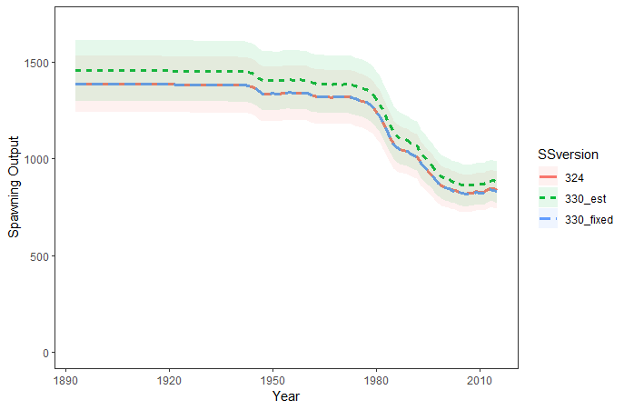

Comparison of spawning output for black rockfish in waters off of Oregon between Stock Synthesis versions 3.24 and 3.30. Uncertainty envelops are 95% confidence intervals.

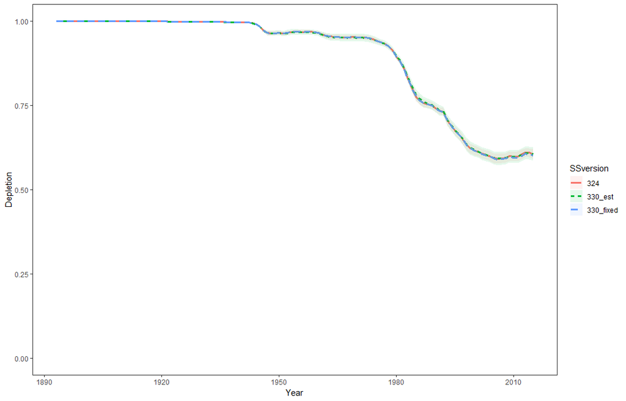

## Unresolved Questions and Issues from the 2015 Assessments

1. Investigation the lack of older (> age 10) females in data. This affects the definition of natural mortality and selectivity values for females.
2. Improved historical catch reconstructions. The trawl fishery catches in particular need attention.
3. Identifying stanzas or periods of uncertainty in the historical catch series will aid in the exploration of catch uncertainty in future assessment sensitivity runs.
4. Treatment of the ODFW tagging study, mainly, the prior value on catchability.
5. Evaluate a nearshore survey.
6. Stock structure for black rockfish.

# Stock Structure

The stock structure of black rockfish continues to be based on state-specific boundaries. Stocks definitions are based on a variety of factors that include genetics, biology, ecology, habitat availability and fishing mortality history. Black rockfish range from southern California up to Alaska. There ecology as a nearshore (i.e., commonly an area of restricted gene flow) rockfish with semi-pelagic behavior (e.g., can demonstrate rare, but substantial adult movements) under strong and differential fishing pressure by state provides an interesting assortment of considerations. A recent genetics study done by Hess et al. (in review) found that Alaskan and west coast populations showed significant genetic difference. The population from Washington to California showed a variety of interesting genetic signatures, with decreased genetic diversity north of Cape Mendocino and North of the Columbia River, but increasing in waters off of Oregon. There were also pockets of isolation by distance and odd signatures off Brookings, Oregon. These variable genetic signatures combined with the lack of consistent black rockfish habitat in southern Washington, and the different exploitation histories in each of the states made state-level designations to support management decisions the most logical. This does not suggest there is no exchange of individuals among California, Oregon and Washington, but instead acknowledges that the exchange is likely low enough not to homogenize the populations, and that different population trends can be expected in each state. This was supported in the results of the last assessment, where important differences in stock status were observed.

# Fleet Structure

Currently, the following fleet structure is being considered for modeling commercial and recreational fisheries in both area models:

1. Commercial fixed-gear Fleet (dead and live fisheries combined)
2. Commercial trawl (mostly a historical fishery)
3. Recreational boat-based
4. Recreational shore-based

Defining fleets is largely based on whether a fishing approach differs in the selectivity (i.e., the capture of fish by length and/or age). Selectivity translates how the removals are taken via length and/or age out of the population. The above four fishery types are distinguished by different fishing activities that result in different selectivities. While in the past the commercial fixed-gear fisheries had been separated by the condition of the landed fish (dead and live), it has been determined that the designation of how the fish will be delivered is a processing issue, not a capture/selectivity issue. Thus the gear selectivity is considered the same in this fleet. This similarity in selectivity is apparent when looking at the 2015 assessment selectivity estimates. For the recreational fishery, the private and charter boat-based fisheries show similar aggregate length compositions and are treated as one fleet (Figure $\ref{fig:private_charter_lts}$). The boat- and shore-based fleets show distinct aggregate compositions that demonstrate the well known characteristic of shore-based landings catching smaller fish (Figure $\ref{fig:boat_shore_lts}$). These recreational fleets are the same treatments as in the 2015 assessment.

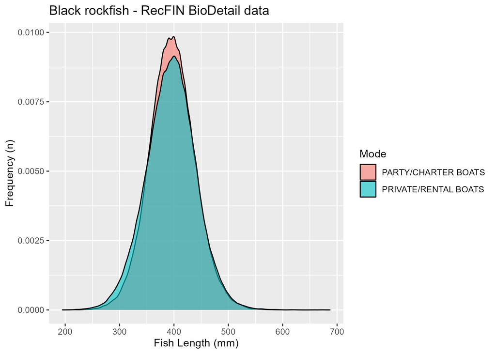

Aggregate length compositions of the private boat and charter boat fisheries. The compositions are not notably different, thus a combined boat-based fishery is used in the assessment.

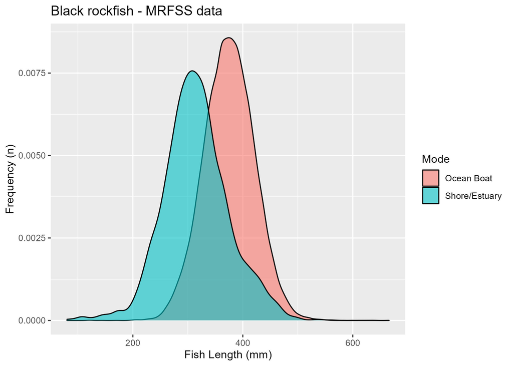

Aggregate length compositions of the boat and shore-based fisheries. The compositions are notably different, thus a boat-based and shore-based fisheries are treated as separate fleets in the assessment.

# Removal Data

## Commerical Landings & Discards

Black rockfish are not considered a major commercial species, but historical reconstructions have shown prominent trawl catches in the past that have subsequently waned over the last 40 years. Historical catch reconstruction were done for the 2015 assessment, and are heavily based on applying highly variable catch compositions to years that do not have those composition, but rather just report total or “unknown” rockfish catches.

When providing data to the 2015 Black rockfish assessment, ODFW staff noted that trawl landings from the 1940s to the 1980s had high year to year variability and an unreasonable magnitude of landings in some years. These data were from the then newly completed [Karnowski et al (2014)](https://www.dfw.state.or.us/mrp/publications/docs/ODFW_Info_Rpt%202014-02_Historic_Reconstruction_Oregon_Commercial_Fish_Landings.pdf) catch reconstruction. ODFW provided an alternative time series that was eventually used in the 2015 assessment (P. Mirick (ODFW) was the main source of this reconstruction). Additionally, the Karnowski et al. (2014) reconstruction did not account for fish taken off of Washington but landed into Oregon, specifically Astoria port landings. The Mirick reconstruction substantially reduced the magnitude of historic trawl catches and stabilized interannual variation in landings compared to the Karnowski et al. (2014) reconstruction. Total rockfish 3A landings were of similar magnitude between the two reconstructions, though different data sources were used in each approach. Species compositions, though, were from the same dataset (Douglas report), but differentially applied. The annual Douglas compositions were used for the Karnowski reconstruction, but these annual compositions were pooled for the Mirick reconstruction. Comparisons of 3A black rockfish from the Douglas report are different than in the Mirick reconstruction but of similar magnitude.

As a part of the 2015 assessment, trawl landings from 3A were also split between OR and WA by using the pooled Douglas compositions and other ODFW sources of information. Static average percentages of black rockfish were applied over multiple decades to allocate fish to WA. The STAT team is still considering the best magnitude of black rockfish in area 3A (dependent on the assumption of black rockfish composition within the to unknown rockfish category) to apply to this OR-WA split. The STAT is also considering further information that may confirm the level of black rockfish in 3A that are landed in Astoria but should be assigned to the Washington state history.

### Items for Discussion

- Absolute magnitude of historical black rockfish catches in Oregon as a percentage unknown rockfish Landings, In particular, trawl catches in the 3A area.
- The allocation of catches in 3A bewtween Oregon and Washington (currently 1.4% and 98.6%, respectively)

## Recreational Landings & Discards

Black rockfish are one of the most important recreational fisheries in Oregon, especially in the boat-based fleets. Boat-bsed landings were reconstructed back in 2015, and only moderate changes were made to the catch history from 2015. A ramp in catch from 1973 to 1979 will complete the series.

For Shore/estuary landings, a more current reconstruction is proposed that uses the filtered weights from MRFSS to reconstruct biomass. A 10 year average of landings from 1996 - 2005 is used to estimate recent landings (2006 - 2022) rather than the 2015 assessment assumption of a linear relationship with fish licenses. There is also a ramp from 1892 - 1979 to account for landings prior to the availability of MRFSS data.

For the final landings time series, estimate of discarded fish will be added. A review of the available data from RecFIN (2001 - 2022) shows an average % discarded of 0.92%. This low amount of discard is consistent with both expectations from management measures and the desireability of black rockfish in the recreational fishery.

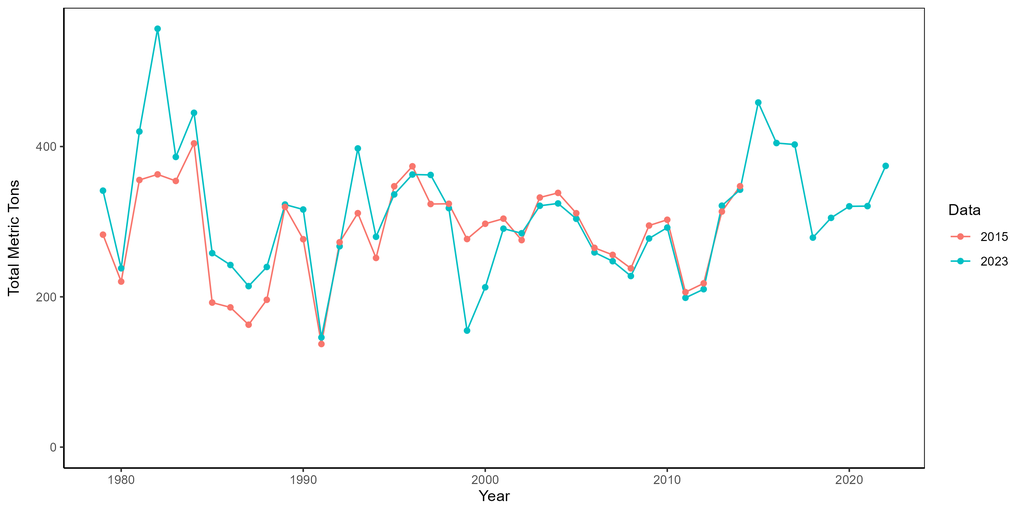

Recreational landings (in mt) for the ocean boat-based fleet used in the 2015 versus that proposed for the 2023 assessment.

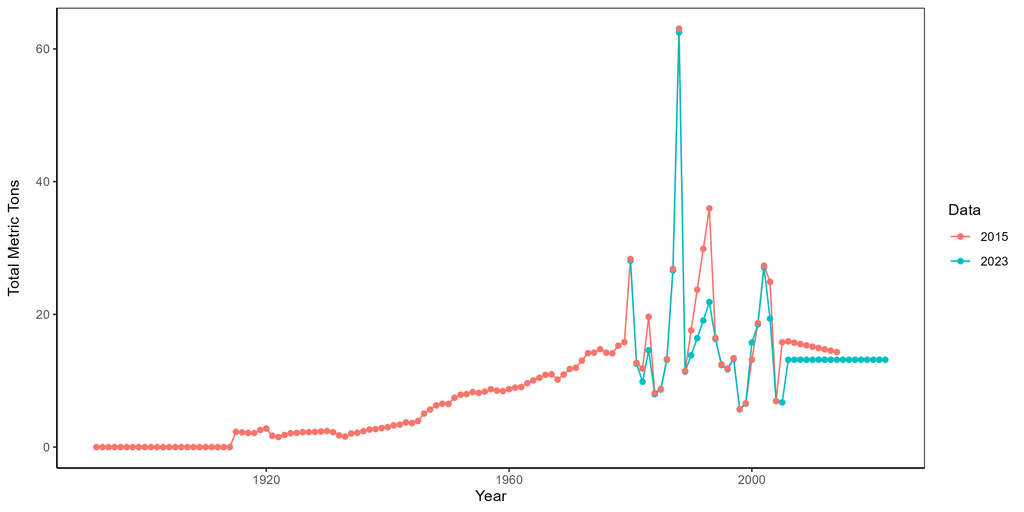

Recreational landings (in mt) for the shore-based fleet used in the 2015 versus that proposed for the 2023 assessment.

### Items for Discussion

There are no major items for discussion regarding the recreational fishery, though there are notable unknowns as far as the historical recreational catches and unsampled shore-based catches. These are not believed to be of a magnitude that should influence assessment output.

# Indices of Abundance

## Fishery-Dependent

# Composition Data

## Commerical length compositions

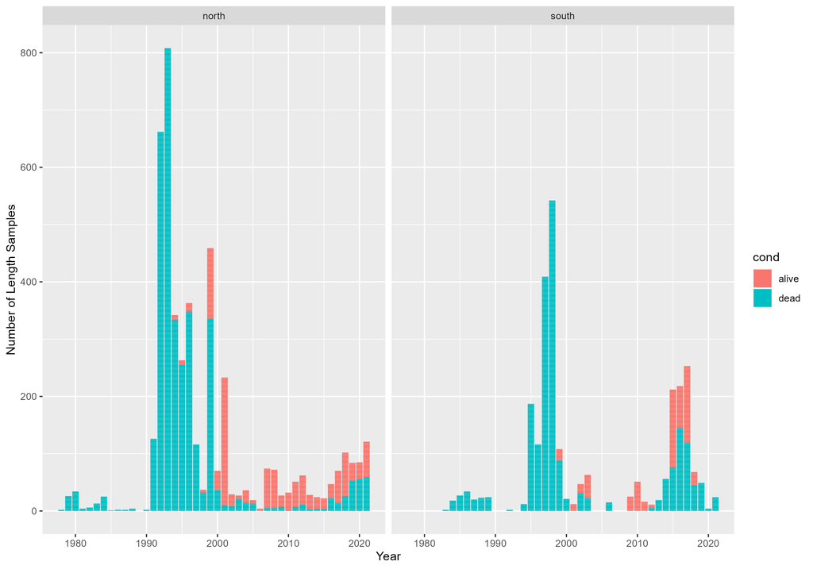

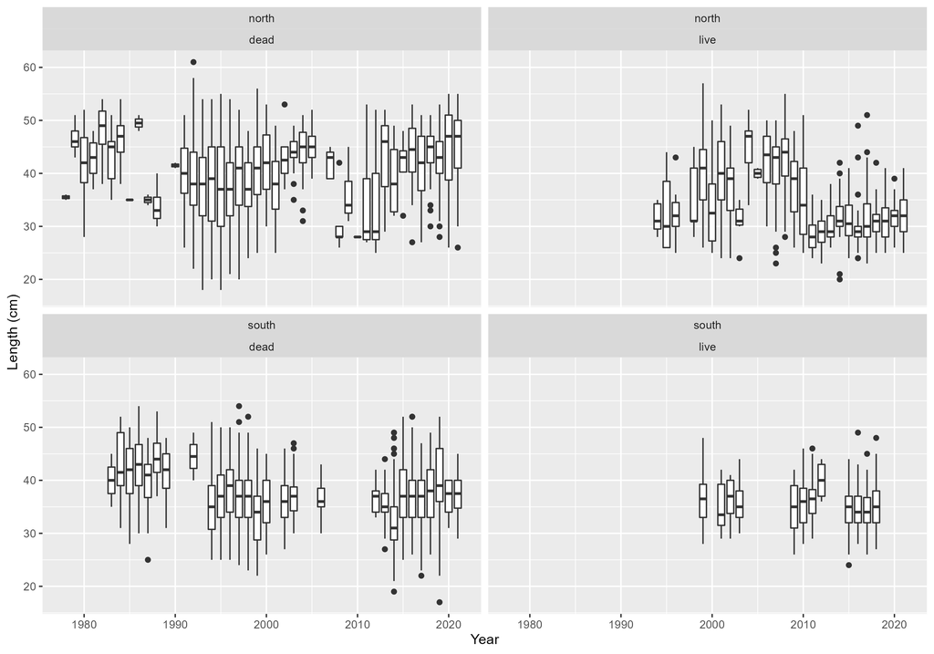

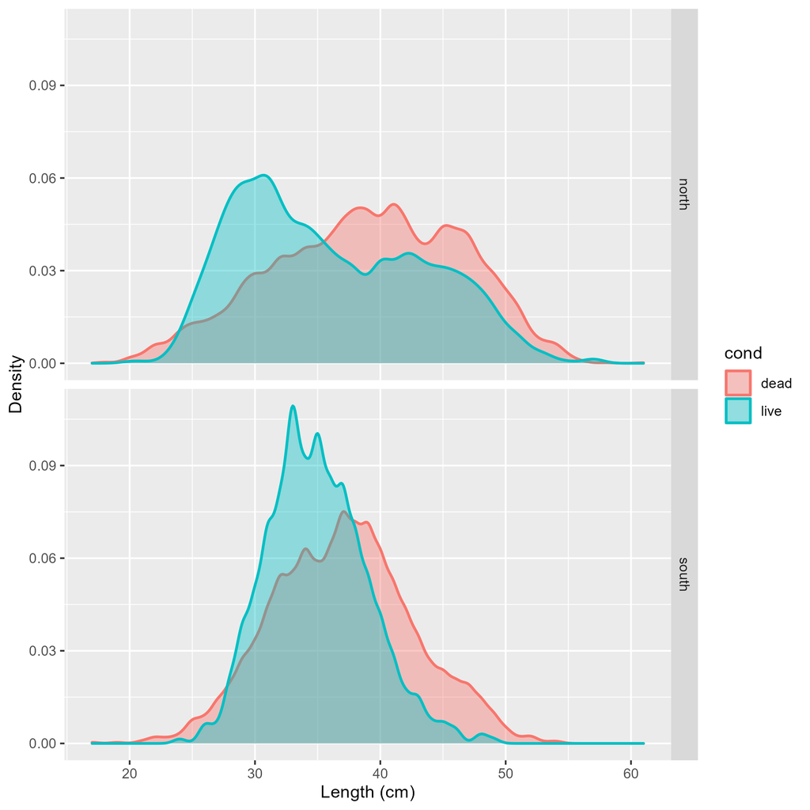

The density of size selected by landed condition, live or dead, for each area across all years (source: PacFIN).

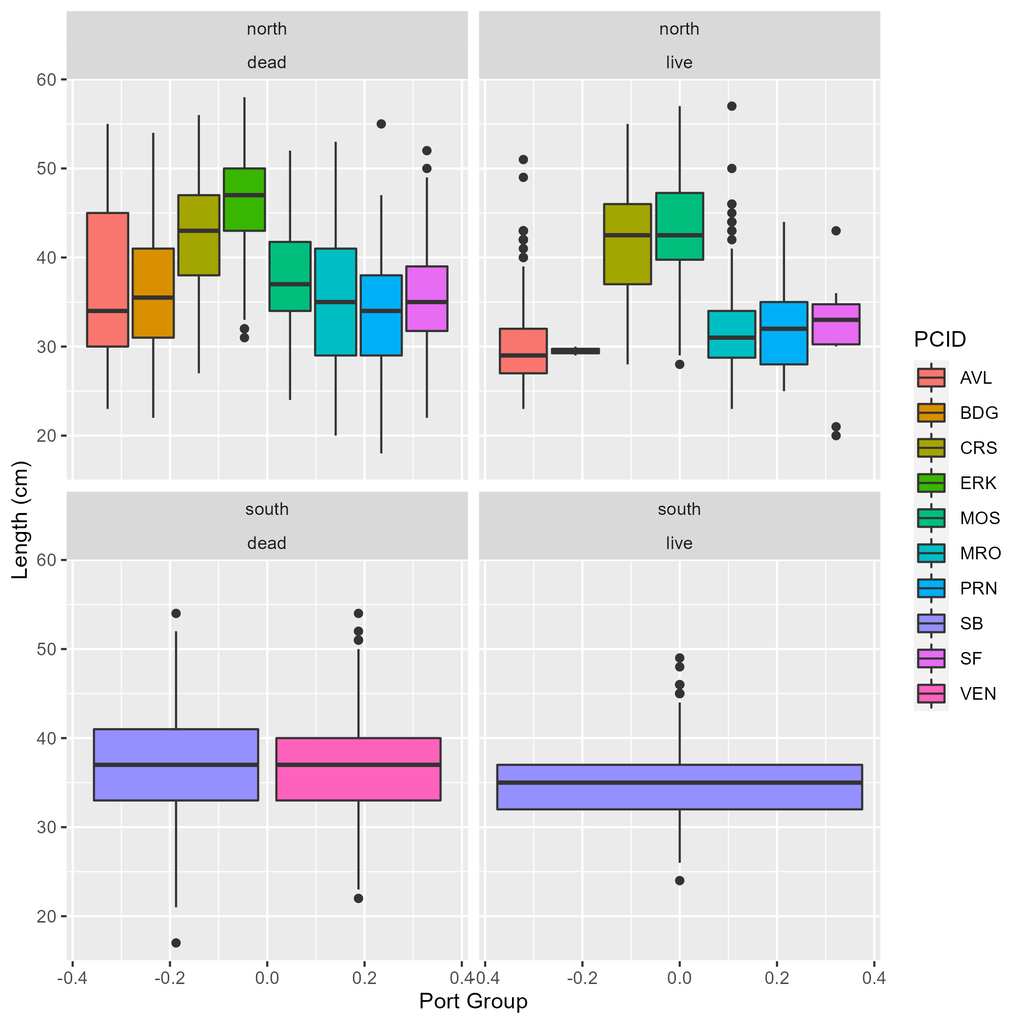

Boxplot of lengths by landed port, area, and fish condition (live or dead). Only ports with greater than 100 length samples (live + dead > 100 samples) across all years are shown (source: PacFIN).

## Recreational length compositions

The recreational length composition data summarized below represen data pulled from RecFIN collected by either the MRFSS (1980 - 2003) or CRFS (2004 - 2022) sampling programs. There are additional data sources that contain historical length samples from the CPFV fleets (1975-1979 from Collins and Crooke, 1987-1998 from Deb Wilson-Vandenberg, and 1986-1989 from Alley and Ono) that will be evaluated and used within each assessment model as appropriate but are not included here.

The total number of length samples within RecFIN across MRFSS and CRFS are:

- North of Point Conception (total lengths = 38,994):
  - 11,969 from CPFV, and
  - 27,025 from Private/Rental vessels.
- South of Point Conception (total lengths = 31,036):
  - 23,535 from CPFV, and
  - 7,501 from Private/Rental vessels.

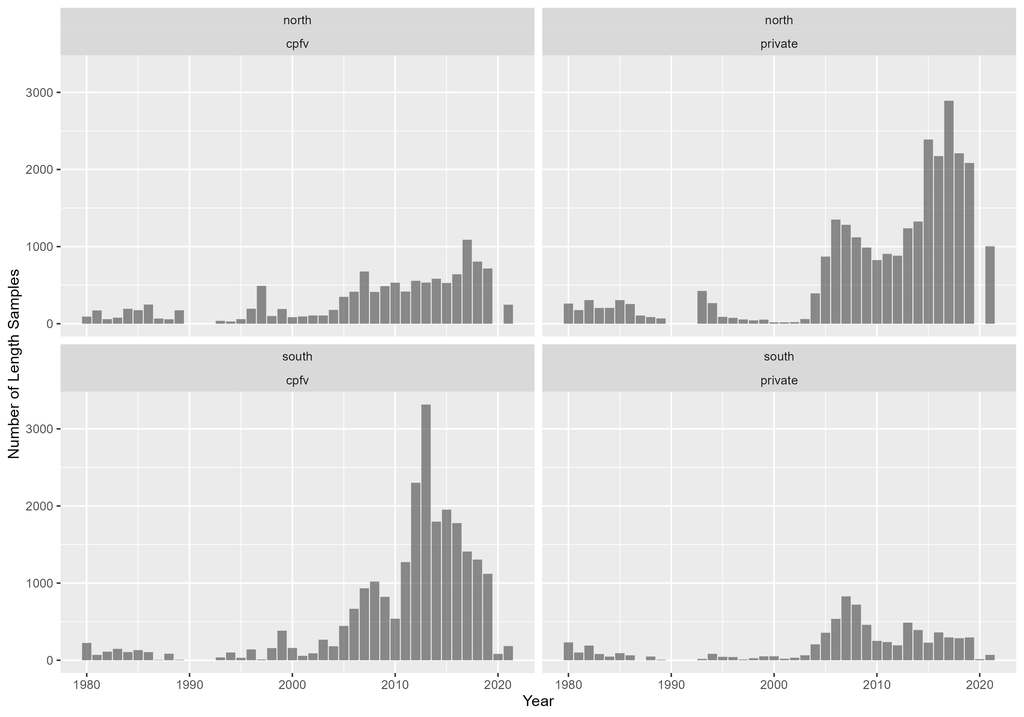

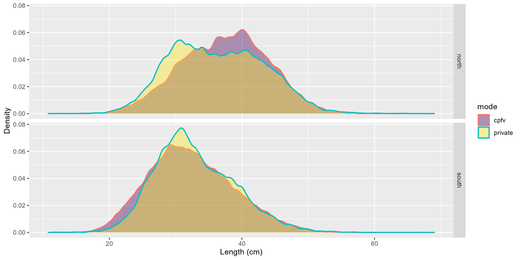

The density of size selected by mode, CPFV or Private/Rental, for each area across all years (source: RecFIN).

# Biology

## Length-Weight

The length-weight relationship was estimated using all biological data available from the NWFSC West Coast Groundfish Bottom Trawl (WCGBT) and the NWFSC Hook and Line surveys.

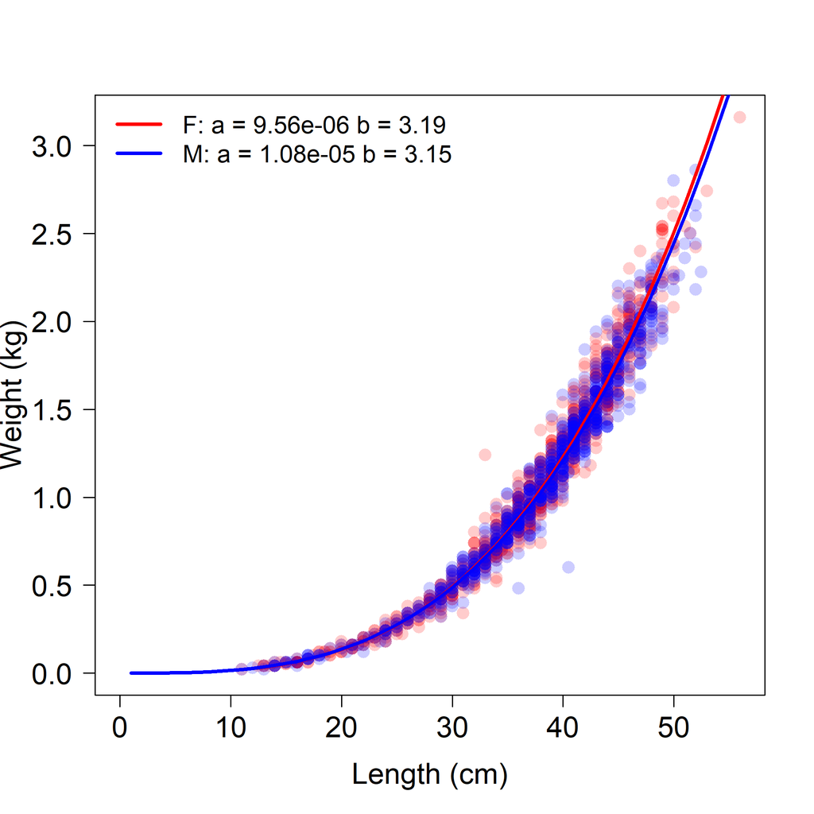

## Natural Mortality

The input parameter value for natural mortality will be reconsidered within the 2023 assessments based on any new available age data. Additionally, the 2023 assessments will explore the ability to estimate natural mortality within the model and will conduct sensitivities and profiles to understand the information in the data on natural mortality and the impact of select values on the model estimates.